# Aula18

Alex

2024-10-03

```
##                         BARUERI GUARULHOS SAO BERNARDO DO CAMPO
## GUARULHOS             3.0502059
## SAO BERNARDO DO CAMPO 0.9323001 2.1650776
## SANTO ANDRE           2.5001673 0.5834756             1.5963142
```

A matriz mostra que os ddos de Garulhos são mais parecidos com os dados de Santo André e que os dados de Barueri são mais parecidos com os dados de SBC.

2. Qual o local mais parecido com Barueri para se abrir uma filial da instituição financeira? Use o código abaixo para apresentar a solução

```r
# instalar a library "leaflet"
library(leaflet)
mapa <- leaflet() %>%
        addTiles() %>%
  addMarkers(
    lng= dados$Longitude,  # inserir os dados com as longitudes
    lat= dados$Latitude,    # inserir os dados com as latitudes
    popup=c("Matriz",
            "Descartar",
            "Possível filial",
            "Descartar"))  # escrever um comentário
mapa
```

[interactive chart not shown]

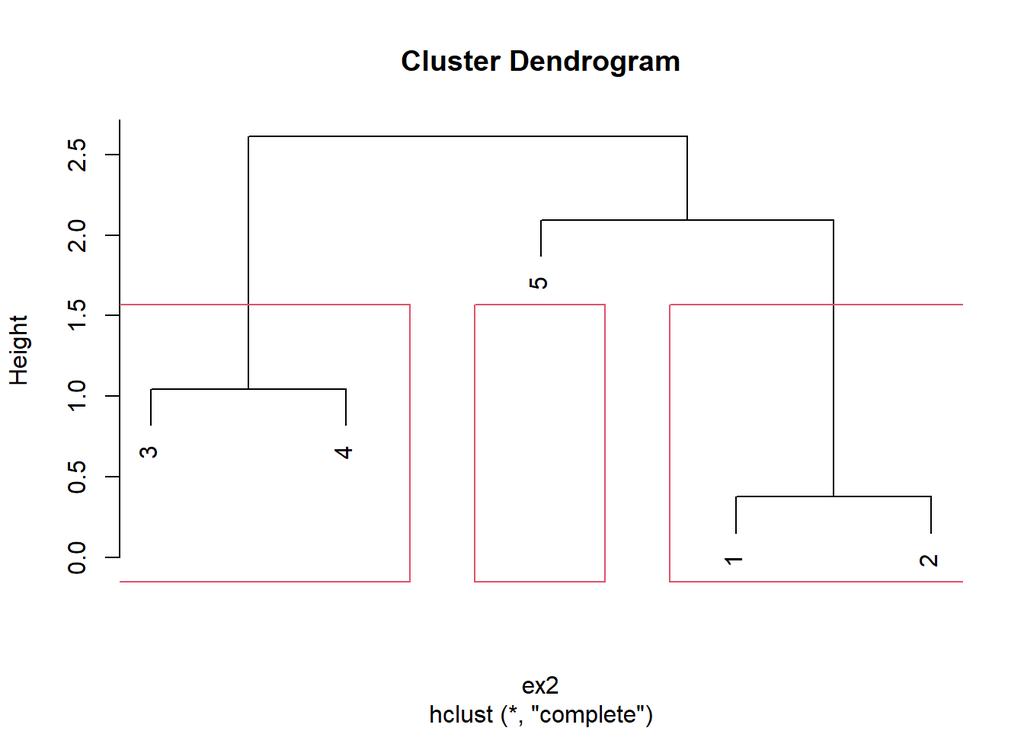

O candidato 1 se parece com o candidato 2 (juniores): pouco tempo de formação e pouco tempo de empresa.

O candidato 3 se parece com o candiddato 4 (seniores): trabalharam desde a formação numa unica empresa.

O candidato 5 tem bastante tempo de formação e pouco tempo da ultima empresa.

3. Um técnico ajustou uma análise de cluster para separar jogadores de futebol, integrantes dos melhores clubes e seleções do mundo, em grupos. Essa avaliação levou em conta a idade dos jogadores, valor de mercado e salário de 2019, e algumas avaliações como reputação internacional e classificação geral e potencial (escores).
1. Qual jogador é o mais distinto de todos os outros?

Ibrahimovic

2. Exclua o jogador mais distinto de todos. Considerando apenas 3 grupos, quais jogadores estão em cada grupo?

Grupo 1: De Godín até Griezmann

Grupo 2: de Súarez até Sergio Ramos

Grupo 3: Messi até Hazard